# CSE 5243 - Introduction to Data Mining

## Homework 1: Exploratory Data Analysis

- Semester: Fall 2021
- Instructor: Greg Ryslik
- Section:Wednesady/Friday 12:45 PM
- Student Name: Bo Yang
- Student Email: yang.6113@osu.edu
- Student ID: 500594333

# Introduction

This homework will focus on a modified version of the kaggle dataset "Pima Indians Diabets Database". It can be found [here](https://www.kaggle.com/uciml/pima-indians-diabetes-database). The overarching objective is to diagnostically predict whether or not a patient has diabetes based upon several other covariates. The full description is shown on the website.

Your task will be to first: 1) Do the prerequisite EDA to understand the data set you will be working on.

2) Fit an appropriate logistic model and analyze it.

While some of the questions have exact answers, a few others are more open to interpretation. However, what we're looking for is the correct thinking and analysis. For the objective questions, while some points are awarded for "the correct number", the majority of the points will be awarded for a proper analysis and logical investigation.

Note: The data has been modified in both some subtle and not-so-subtle ways. You're welcome to look at other previous work online (in kaggle, stack overflow, etc -- and in fact that's critical to learning how to write good code!) but be wary about just using other people's work. It would both be a violation of the academic code of conduct, but it may also lead you down the wrong path.

### Collaboration

For this assignment, you should work as an individual. You may informally discuss ideas with classmates, but your work should be your own.

### What you need to turn in:

1) Code

- For this homework, the code is the Jupyter Notebook. Use the provided Jupyter Notebook template, and fill in the appropriate information.
- You may use common Python libraries for I/O, data manipulation, data visualization, etc. (e.g., NumPy, Pandas, MatPlotLib,… See reference below.)
- You may not use library operations that perform, in effect, the “core” computations for this homework (e.g., If the assignment is to write a K-Means algorithm, you may not use a library operation that, in effect, does the core work needed to implement a K-Means algorithm.). When in doubt, ask the grader or instructor.
- The code must be written by you, and any significant code snips you found on the Internet and used to understand how to do your coding for the core functionality must be attributed. (You do not need to attribute basic functionality – matrix operations, IO, etc.)
- The code must be commented sufficiently to allow a reader to understand the algorithm without reading the actual Python, step by step.
- When in doubt, ask the grader or instructor.

2) Written Report

- For this homework, the report is the Jupyter Notebook. The report should be well-written. Please proof-read and remove spelling and grammar errors and typos.
- The report should discuss your analysis and observations. Key points and findings must be written in a style suitable for consumption by non-experts. Present charts and graphs to support your observations. If you performed any data processing, cleaning, etc., please discuss it within the report.

### Grading

1. Overall readability and organization of your report (10%)
   > - Is it well organized and does the presentation flow in a logical manner?
   > - Are there no grammar and spelling mistakes?
   > - Do the charts/graphs relate to the text?
   > - Are the summarized key points and findings understandable by non-experts?
   > - Do the Overview and Conclusions provide context for the entire exercise?
2. Domain Understanding Phase (10%)
   > - Did you provide a reasonable level of information?
3. Data Understanding Phase (30%)
   > - Did you find novel and/or interesting insights, or did you solely focus on simple summarizations of the data?
   > - Did you draw and present potential conclusion or observations from your analysis of the data?
   > - Did the statistics and visualizations you used make sense in the context of the data?
4. Data Analysis Phase (40%)
   > - Did you correctly do the data cleaning steps and perform the appropriate logistic regression.
   > - Was your analysis of the significant variables appropriate.
   > - How have you justified your feature transformation and/or feature creation steps.
5. Conclusions (10%)
   > - Did you summarize appropriately your critical findings.
   > - Did you provide appropriate conclusions and next steps.

### How to turn in your work on Carmen:

Submit to Carmen the Jupyter Notebook, the html print out of your Jupyter notebook, and any supporting files that you used to process and analyze this data. You do not need to include the input data. All submitted files (code and/or report) except for the data should be archived in a *.zip file, and submitted via Carmen. Use this naming convention:

• Project1_Surname_DotNumber.zip

The submitted file should be less than 10MB.

# Section 0: Setup

- Add any needed imports, helper functions, etc., here.

```python
import numpy as np
import pandas as pd
import matplotlib.pyplot as plt
import seaborn as sns
from scipy.stats import chi2_contingency
from scipy.stats import chi2
from sklearn.preprocessing import MinMaxScaler
import sklearn as sk
import statsmodels.api as sm
import statsmodels.formula.api as smf
import os
from sklearn.linear_model import LogisticRegression
from sklearn.model_selection import train_test_split
from sklearn.metrics import accuracy_score,classification_report
from sklearn.metrics import roc_auc_score,roc_curve
```

# Section: 1 - Domain Understanding

- Write a few paragraphs providing an overview of the data. Some questions you should consider are: Where did the data come from? What do the rows represent? Why and how was the data collected? Who might use this data? What types of questions might users be able to analyze with this data?
- You should review the dataset description information on the webpage to get some context. Of course you will only have limited background on this topic (and you are not expected to become an expert), so do your best to imagine the context for the work, making reasonable assumptions as appropriate. At this stage, you are not analyzing individual attributes, but discussing the dataset in aggregate.

### Data description：

> - This dataset is originally from the National Institute of Diabetes and Digestive and Kidney Diseases.
> - In particular, all patients here are females at least 21 years old of Pima Indian heritage.
> - The datasets consists of several medical predictor variables and one target variable, Outcome. Predictor variables includes the number of pregnancies the patient has had, their BMI, insulin level, age, and so on.

### Use of data：

> - The objective of the dataset is to diagnostically predict whether or not a patient has diabetes, based on certain diagnostic measurements included in the dataset. Several constraints were placed on the selection of these instances from a larger database.
> - From this data set, researchers and medical professionals can generalize indicators that are highly relevant to diabetes patients.

### Assumptions:

> - Some indicators contribute to diabetes predictions, but such predictions can be highly volatile. The combination of multiple indicators can predict diabetes outcomes more accurately. Some of the indicators are not helpful individually, but they can be very illuminating when looked at together with other indicators.
> - Some exceptions or default values can affect the prediction results.

# Section: 2 - Data Understanding

- Perform exploratory data analysis of the dataset by looking at individual attributes and/or combinations of attributes. You should focus on identifying and describing interesting observations and insights that you might uncover from the data.
- You should not simply provide the basic EDA information for all attributes in the data (although that's a good first step!). Instead, you should focus on those that are more interesting or important, and provide some discussion of what you observe. Pay particular attention to potentially interesting bivariate (two-variable) relationships, as well as the relationship between each attribute and the outcome.

## Section: 2.1 - Describe the meaning and type of data for each feature.

```python
data = pd.read_csv("diabetes_hw_data_3494.csv",header = 0, names = ['Pregnancies','Glucose','BloodPressure','SkinThickness','Insulin','BMI','DiaetesPedigreeFunction','Age','Outcome'])
#read data from diabetes_hw_data_3494.csv
data
#rows represent:
```

|  | Pregnancies | Glucose | BloodPressure | SkinThickness | Insulin | BMI | DiaetesPedigreeFunction | Age | Outcome |
| --- | --- | --- | --- | --- | --- | --- | --- | --- | --- |
| 0 | 5.0 | 144 | 82.0 | 26.0 | 285.0 | 32.0 | 0.452 | 58.0 | 1 |
| 1 | 5.0 | 137 | 108.0 | 0.0 | 0.0 | 48.8 | 0.227 | 37.0 | 1 |
| 2 | 5.0 | 109 | 75.0 | 26.0 | 0.0 | 36.0 | 0.546 | 60.0 | 0 |
| 3 | 3.0 | 113 | 50.0 | 10.0 | 85.0 | 29.5 | 0.626 | 25.0 | 0 |
| 4 | 2.0 | 96 | 68.0 | 13.0 | 49.0 | 21.1 | 0.647 | 26.0 | 0 |
| ... | ... | ... | ... | ... | ... | ... | ... | ... | ... |
| 778 | 1.0 | 71 | 48.0 | 18.0 | 76.0 | 20.4 | 0.323 | 22.0 | 0 |
| 779 | 2.0 | 112 | 78.0 | 50.0 | 140.0 | 39.4 | 0.175 | 24.0 | 0 |
| 780 | 0.0 | 138 | 0.0 | 0.0 | 0.0 | 36.3 | 0.933 | 25.0 | 1 |
| 781 | 4.0 | 183 | 0.0 | 0.0 | 0.0 | 28.4 | 0.212 | 36.0 | 1 |
| 782 | 8.0 | 183 | 448.0 | 0.0 | 0.0 | 23.3 | 0.672 | 32.0 | 1 |

783 rows × 9 columns

```python
data.describe()
```

|  | Pregnancies | Glucose | BloodPressure | SkinThickness | Insulin | BMI | DiaetesPedigreeFunction | Age | Outcome |
| --- | --- | --- | --- | --- | --- | --- | --- | --- | --- |
| count | 783.000000 | 783.000000 | 783.000000 | 783.000000 | 783.000000 | 783.000000 | 783.000000 | 783.000000 | 783.000000 |
| mean | 3.841635 | 121.280971 | 70.726692 | 20.968072 | 82.762452 | 32.360409 | 0.470271 | 34.444444 | 0.348659 |
| std | 3.366824 | 32.325356 | 31.374634 | 18.732339 | 121.761453 | 11.463401 | 0.330093 | 25.167961 | 0.476850 |
| min | 0.000000 | 0.000000 | 0.000000 | 0.000000 | 0.000000 | 0.000000 | 0.078000 | 21.000000 | 0.000000 |
| 25% | 1.000000 | 99.000000 | 63.000000 | 0.000000 | 0.000000 | 27.350000 | 0.242000 | 24.000000 | 0.000000 |
| 50% | 3.000000 | 117.000000 | 72.000000 | 23.000000 | 36.000000 | 32.000000 | 0.370000 | 29.000000 | 0.000000 |
| 75% | 6.000000 | 141.000000 | 80.000000 | 32.000000 | 130.000000 | 36.600000 | 0.625000 | 41.000000 | 1.000000 |
| max | 17.000000 | 199.000000 | 504.000000 | 273.000000 | 846.000000 | 264.600000 | 2.420000 | 567.000000 | 1.000000 |

- Pregancies: Number of times pregnant.
- Glucose: Plasma glucose concentration a 2 hours in an oral glucose tolerance test.
- BloodPressure: Diastolic blood pressure (mm Hg).
- SkinThickness: Triceps skin fold thickness (mm).
- Insulin: 2-Hour serum insulin (mu U/ml).
- BMI: Body mass index (weight in kg/(height in m)^2).
- Diabetes pedigree function: A function that scores the likelihood of diabetes based on family history.
- Age: Age (years).

## Section: 2.2 - Provide basic statistics for the attributes.

- For example: counts, percentiles, mean, median, standard deviation. The statistics should be relevant for the type of attribute.

```python
data['Outcome'].value_counts()
```

```
0    510
1    273
Name: Outcome, dtype: int64
```

```python
data.quantile(q = [0, 0.01, .1, .25, .5, .75, .9, .99, 1])
```

|  | Pregnancies | Glucose | BloodPressure | SkinThickness | Insulin | BMI | DiaetesPedigreeFunction | Age | Outcome |
| --- | --- | --- | --- | --- | --- | --- | --- | --- | --- |
| 0.00 | 0.0 | 0.0 | 0.00 | 0.0 | 0.0 | 0.00 | 0.07800 | 21.00 | 0.0 |
| 0.01 | 0.0 | 57.0 | 0.00 | 0.0 | 0.0 | 0.00 | 0.09528 | 21.00 | 0.0 |
| 0.10 | 0.0 | 85.0 | 54.00 | 0.0 | 0.0 | 23.62 | 0.16400 | 22.00 | 0.0 |
| 0.25 | 1.0 | 99.0 | 63.00 | 0.0 | 0.0 | 27.35 | 0.24200 | 24.00 | 0.0 |
| 0.50 | 3.0 | 117.0 | 72.00 | 23.0 | 36.0 | 32.00 | 0.37000 | 29.00 | 0.0 |
| 0.75 | 6.0 | 141.0 | 80.00 | 32.0 | 130.0 | 36.60 | 0.62500 | 41.00 | 1.0 |
| 0.90 | 9.0 | 168.0 | 88.00 | 40.0 | 215.0 | 42.08 | 0.87740 | 51.00 | 1.0 |
| 0.99 | 13.0 | 196.0 | 108.36 | 54.0 | 545.0 | 52.30 | 1.69818 | 67.18 | 1.0 |
| 1.00 | 17.0 | 199.0 | 504.00 | 273.0 | 846.0 | 264.60 | 2.42000 | 567.00 | 1.0 |

### Measures of Location

$\mbox{The}$ **mean** is the most common measure of the location of a set of points. Assuming that there are $m$ observations with values $x_i$:

$$ mean(x) = \bar{x}= \frac{1}{m}\sum_{i=1}^m x_i $$

However, the mean is very sensitive to outliers.

Thus, the **median** (middle value, or 50th percentile) is also commonly used.

```python
data.mean()
```

```
Pregnancies                  3.841635
Glucose                    121.280971
BloodPressure               70.726692
SkinThickness               20.968072
Insulin                     82.762452
BMI                         32.360409
DiaetesPedigreeFunction      0.470271
Age                         34.444444
Outcome                      0.348659
dtype: float64
```

```python
data.median()
```

```
Pregnancies                  3.00
Glucose                    117.00
BloodPressure               72.00
SkinThickness               23.00
Insulin                     36.00
BMI                         32.00
DiaetesPedigreeFunction      0.37
Age                         29.00
Outcome                      0.00
dtype: float64
```

### Measures of Spread: Range and Variance

The **Range** is the difference between the max (largest) and min (smallest) observations for a particular attributes.

The **variance** is the most common measure of the spread of a set of points.

$$ variance(x) = s_x^2 = \frac{1}{m-1}\sum_{i=1}^m (x_i - \bar{x})^2 $$

The **standard deviation** is the square root of the variance:

$$ stdev(x) = s_x = \sqrt{\frac{1}{m-1}\sum_{i=1}^m (x_i - \bar{x})^2} $$

One problem with all three of these measures is that they are all sensitive to outliers. Numerous other measures have been proposed:

$$ \mbox{Mean Absolute Deviation}(x) = MAD(x) = \frac{1}{m}\sum_{i=1}^m \mid x_i - \bar{x} \mid $$$$ \mbox{Interquartile Range}(x) = IQR(x) = x_{75} - x_{25} $$

```python
data.std()
```

```
Pregnancies                  3.366824
Glucose                     32.325356
BloodPressure               31.374634
SkinThickness               18.732339
Insulin                    121.761453
BMI                         11.463401
DiaetesPedigreeFunction      0.330093
Age                         25.167961
Outcome                      0.476850
dtype: float64
```

```python
data.var()
```

```
Pregnancies                   11.335502
Glucose                     1044.928627
BloodPressure                984.367663
SkinThickness                350.900514
Insulin                    14825.851427
BMI                          131.409556
DiaetesPedigreeFunction        0.108962
Age                          633.426257
Outcome                        0.227386
dtype: float64
```

```python
data.max(numeric_only = True) - data.min(numeric_only = True)
```

```
Pregnancies                 17.000
Glucose                    199.000
BloodPressure              504.000
SkinThickness              273.000
Insulin                    846.000
BMI                        264.600
DiaetesPedigreeFunction      2.342
Age                        546.000
Outcome                      1.000
dtype: float64
```

```python
data.mad()
```

```
Pregnancies                 2.770335
Glucose                    25.500330
BloodPressure              13.962749
SkinThickness              14.072975
Insulin                    87.718618
BMI                         6.151168
DiaetesPedigreeFunction     0.246672
Age                        11.001277
Outcome                     0.454192
dtype: float64
```

```python
data.quantile(.75) - data.quantile(.25)
```

```
Pregnancies                  5.000
Glucose                     42.000
BloodPressure               17.000
SkinThickness               32.000
Insulin                    130.000
BMI                          9.250
DiaetesPedigreeFunction      0.383
Age                         17.000
Outcome                      1.000
dtype: float64
```

## Section: 2.3 - Visualize the most important or interesting attributes using appropriate techniques.

- For each visualization, provide an interpretation explaining why it is appropriate or interesting. What does each visualization tell us?

### Histogram

> - The histogram shows the distribution of values for a single variable.
> - The histogram shows missing values, duplicate data, or outliers easily.

### Boxplots

> - The boxplot is useful for visually representing the distribution of a single attribute.
> - The boxplot can also show missing values, duplicate data, or outliers easily.

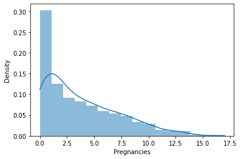

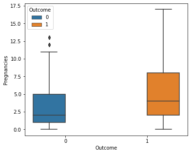

```python
sns.histplot(data['Pregnancies'], kde=True, stat="density", linewidth=0)
plt.figure(figsize=(6,5))
sns.boxplot(y=data['Pregnancies'], x = data['Outcome'], hue = data['Outcome'])
```

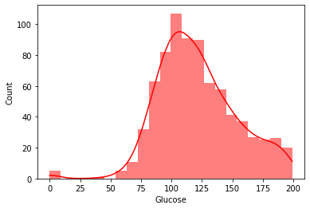

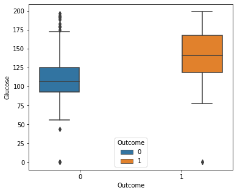

```python
sns.histplot(data['Glucose'], color="red", kde=True,  linewidth=0)
plt.figure(figsize=(6,5))
sns.boxplot(y=data['Glucose'], x = data['Outcome'], hue = data['Outcome'])
```

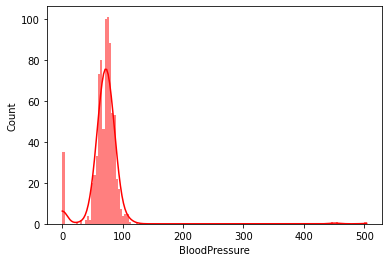

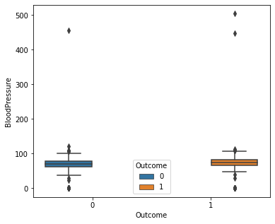

```python
sns.histplot(data['BloodPressure'], color="red", kde=True, linewidth=0)
plt.figure(figsize=(6,5))
sns.boxplot(y=data['BloodPressure'], x = data['Outcome'], hue = data['Outcome'])
```

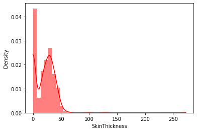

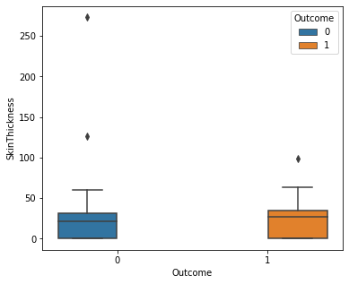

```python
sns.histplot(data['SkinThickness'], color="red",kde=True, stat="density", linewidth=0)
plt.figure(figsize=(6,5))
sns.boxplot(y=data['SkinThickness'], x = data['Outcome'], hue = data['Outcome'])
```

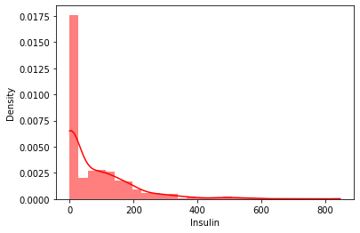

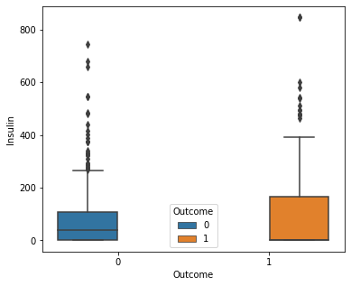

```python
sns.histplot(data['Insulin'], color="red",kde=True, stat="density", linewidth=0)
plt.figure(figsize=(6,5))
sns.boxplot(y=data['Insulin'], x = data['Outcome'], hue = data['Outcome'])
```

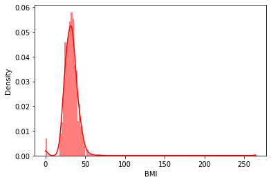

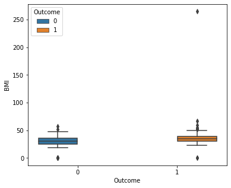

```python
sns.histplot(data['BMI'], color="red",kde=True, stat="density", linewidth=0)
plt.figure(figsize=(6,5))
sns.boxplot(y=data['BMI'], x = data['Outcome'], hue = data['Outcome'])
```

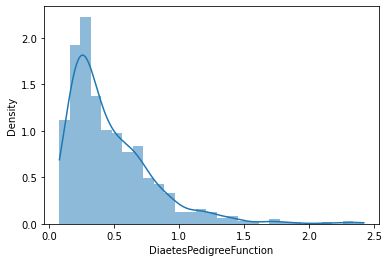

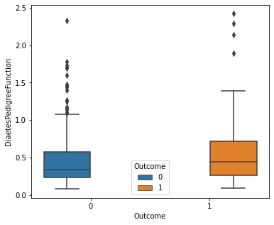

```python
sns.histplot(data['DiaetesPedigreeFunction'],kde=True, stat="density", linewidth=0)
plt.figure(figsize=(6,5))
sns.boxplot(y=data['DiaetesPedigreeFunction'], x = data['Outcome'], hue = data['Outcome'])
```

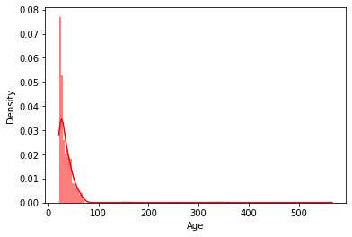

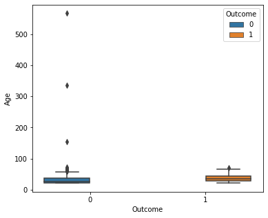

```python
sns.histplot(data['Age'],color="red",kde=True, stat="density", linewidth=0)
plt.figure(figsize=(6,5))
sns.boxplot(y=data['Age'], x = data['Outcome'], hue = data['Outcome'])
```

## Section: 2.4 - Verify data quality: explain any missing values, duplicate data, or outliers.

- What, if anything, do you need to do about these? Be specific.

### Duplicate data：

index of duplicate data: 218, 226, 399, 408, 416, 462, 486, 521, 543, 576, 607, 613, 614, 726, 728

```python
data = data[data.duplicated(keep=False)]
data = data.groupby(data.columns.tolist()).apply(lambda x: tuple(x.index)).tolist()
print (data)
```

```
[(695, 726), (79, 521), (431, 462), (493, 607), (185, 408, 576), (370, 543), (264, 614), (285, 416), (139, 399), (276, 728), (41, 486), (140, 218, 613), (39, 226)]
```

### Outliers are out the normal boundies ( boundies as follows )：

- Pregnancies: Q3+1.5IQR=13.5,but it is possible to be pregnant 17 times. So, there is no outliers.
- Glucose:Generally, normal blood glucose is between 3.9-6.1 mmol/L, and 70.2-109.8 after conversion. Due to our special data set, pregnant women need to be considered, and their postprandial blood glucose is generally 8.5mmol/L, which is 153 or higher after conversion. So, there is no outliers.
- BloodPressure：Q1-1.5IQR=37.5,Q3+1.5IQR=105,but it is possible to be 108.36 or 24, so outliers>110.
- SkinThickness: Q3+1.5IQR=80,so outliers>80
- Insulin: Q3+1.5IQR=325,so outliers>325
- BMI：Q3+1.5IQR=50.5,so outliers>50.5
- DiaetesPedigreeFunction:Q3+1.5IQR=1.20,so outliers>1.20
- Age: outliers > 100

Q1-1.5IQR:

```python
data = pd.read_csv("diabetes_hw_data_3494.csv",header = 0, names = ['Pregnancies','Glucose','BloodPressure','SkinThickness','Insulin','BMI','DiaetesPedigreeFunction','Age','Outcome'])
data.quantile(.25) - 1.5*(data.quantile(.75) - data.quantile(.25))
```

```
Pregnancies                 -6.5000
Glucose                     36.0000
BloodPressure               37.5000
SkinThickness              -48.0000
Insulin                   -195.0000
BMI                         13.4750
DiaetesPedigreeFunction     -0.3325
Age                         -1.5000
Outcome                     -1.5000
dtype: float64
```

Q3+1.5IQR:

```python
data.quantile(.75) + 1.5*(data.quantile(.75) - data.quantile(.25))
```

```
Pregnancies                 13.5000
Glucose                    204.0000
BloodPressure              105.5000
SkinThickness               80.0000
Insulin                    325.0000
BMI                         50.4750
DiaetesPedigreeFunction      1.1995
Age                         66.5000
Outcome                      2.5000
dtype: float64
```

## Section: 2.5 - Explore the relationships among the features, excluding the outcome attribute.

- Use scatter plots, correlation matrices, cross-tabulations, group-wise averages, or other appropriate techniques. Explain and interpret any interesting relationships.

### Scatterplots

Scatterplots are used to visually show the relationship between attributes.

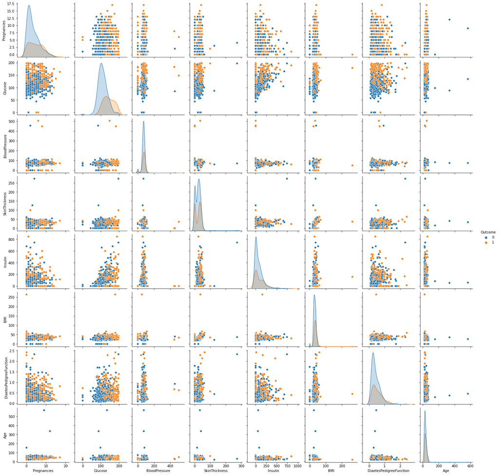

```python
data = pd.read_csv("diabetes_hw_data_3494.csv",header = 0, names = ['Pregnancies','Glucose','BloodPressure','SkinThickness','Insulin','BMI','DiaetesPedigreeFunction','Age','Outcome'])
sns.pairplot(data, hue = "Outcome");
```

### Covariance

The **covariance** measures the relationship between independent variables and is defined as follows (assuming that there are $m$ observations):

$$ s_{j, k} = cov(x_j, x_k) = \frac{1}{m-1} \sum_{i=1}^m (x_{ij} - \bar{x}_j)(x_{ik} - \bar{x}_k) $$

$ $The **covariance matrix** ${\bf S}$ is an $n \times n$ matrix

$$ {\bf S} = \begin{bmatrix} s_{11} & s_{12} \ldots & s_{1n}\\ s_{21} & s_{22} \ldots & s_{2n}\\ & \ldots & \\ s_{n1} & s_{n2} \ldots & s_{nn} \end{bmatrix} $$

$ $Note that the diagonal entries $s_{jj}$ of ${\bf S}$ are the variances of the attribute $x_j$.

```python
data.cov()
```

|  | Pregnancies | Glucose | BloodPressure | SkinThickness | Insulin | BMI | DiaetesPedigreeFunction | Age | Outcome |
| --- | --- | --- | --- | --- | --- | --- | --- | --- | --- |
| Pregnancies | 11.335502 | 14.392379 | 11.752059 | -4.657237 | -34.629739 | -0.535306 | -0.044039 | 26.982239 | 0.368585 |
| Glucose | 14.392379 | 1044.928627 | 116.817299 | 42.556297 | 1308.061714 | 72.080320 | 1.386201 | 92.057829 | 7.190914 |
| BloodPressure | 11.752059 | 116.817299 | 984.367663 | 49.825022 | 45.028344 | 38.005150 | 0.657404 | 65.158710 | 1.103086 |
| SkinThickness | -4.657237 | 42.556297 | 49.825022 | 350.900514 | 1010.970667 | 52.735691 | 1.563016 | -10.925689 | 0.347464 |
| Insulin | -34.629739 | 1308.061714 | 45.028344 | 1010.970667 | 14825.851427 | 189.565263 | 6.949617 | -72.098892 | 6.761957 |
| BMI | -0.535306 | 72.080320 | 38.005150 | 52.735691 | 189.565263 | 131.409556 | 0.343558 | -3.317548 | 1.286456 |
| DiaetesPedigreeFunction | -0.044039 | 1.386201 | 0.657404 | 1.563016 | 6.949617 | 0.343558 | 0.108962 | 0.033644 | 0.025845 |
| Age | 26.982239 | 92.057829 | 65.158710 | -10.925689 | -72.098892 | -3.317548 | 0.033644 | 633.426257 | 0.981671 |
| Outcome | 0.368585 | 7.190914 | 1.103086 | 0.347464 | 6.761957 | 1.286456 | 0.025845 | 0.981671 | 0.227386 |

### Correlation

$\mbox{The}$ **correlation** $r_{jk}$ between $x_j$ and $x_k$ is defined as:

$$ r_{jk} = \frac{s_{jk}}{\sqrt{s_{jj}s_{kk}}} $$

Correlation normalizes the covariance by dividing the covariance by the square root of the individual variances. Therefore, the correlation ranges from -1 to +1.

Correlation measures the linear relationship between two continuous attributes.

```python
data.corr()
```

|  | Pregnancies | Glucose | BloodPressure | SkinThickness | Insulin | BMI | DiaetesPedigreeFunction | Age | Outcome |
| --- | --- | --- | --- | --- | --- | --- | --- | --- | --- |
| Pregnancies | 1.000000 | 0.132242 | 0.111254 | -0.073844 | -0.084473 | -0.013870 | -0.039626 | 0.318427 | 0.229581 |
| Glucose | 0.132242 | 1.000000 | 0.115182 | 0.070279 | 0.332334 | 0.194518 | 0.129911 | 0.113154 | 0.466508 |
| BloodPressure | 0.111254 | 0.115182 | 1.000000 | 0.084777 | 0.011787 | 0.105670 | 0.063477 | 0.082517 | 0.073731 |
| SkinThickness | -0.073844 | 0.070279 | 0.084777 | 1.000000 | 0.443238 | 0.245583 | 0.252775 | -0.023174 | 0.038899 |
| Insulin | -0.084473 | 0.332334 | 0.011787 | 0.443238 | 1.000000 | 0.135811 | 0.172908 | -0.023527 | 0.116461 |
| BMI | -0.013870 | 0.194518 | 0.105670 | 0.245583 | 0.135811 | 1.000000 | 0.090792 | -0.011499 | 0.235342 |
| DiaetesPedigreeFunction | -0.039626 | 0.129911 | 0.063477 | 0.252775 | 0.172908 | 0.090792 | 1.000000 | 0.004050 | 0.164197 |
| Age | 0.318427 | 0.113154 | 0.082517 | -0.023174 | -0.023527 | -0.011499 | 0.004050 | 1.000000 | 0.081797 |
| Outcome | 0.229581 | 0.466508 | 0.073731 | 0.038899 | 0.116461 | 0.235342 | 0.164197 | 0.081797 | 1.000000 |

### Heat map

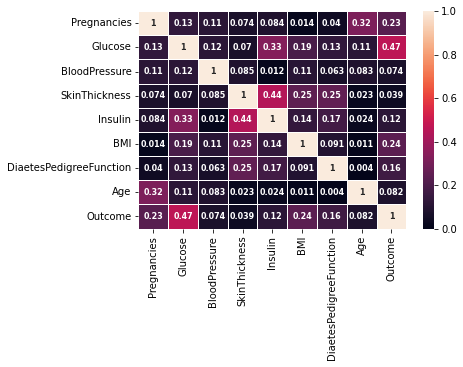

```python
correlations = data.corr()
correction=abs(correlations)
fig = plt.figure()
ax = sns.heatmap(correction, linewidths=0.5,vmax=1, vmin=0 ,annot=True,annot_kws={'size':8,'weight':'bold'})
plt.xticks(np.arange(9)+0.5)
plt.yticks(np.arange(9)+0.5)
plt.show()
```

### Explore the relationships among the features：

- Age & Pregancies: The correlation between the number of pregnancies and age is clear. The older you get, the more pregnancies you're likely to have.
- Insulin & Glucose: The correlation between insulin content and blood glucose content was also significant, and the two were positively correlated.
- Skin thickness & Insulin: There was a strong correlation between insulin levels and skin thickness. This is a bit of a surprise.
- Skin thickness & BMI: It's not unusual for skin thickness to be correlated with BMI. The thicker the skin, the more fat it is likely to have, so the higher the BMI. The correlation between BMI and insulin levels was supposed to be high, but it turned out not to be.
- Skin thickness & DP function: There was also a high correlation between skin thickness and DP function.

## Section: 2.6 - Identify and explain any interesting relationships between the outcome attribute and the other attributes.

- You may refer to earlier visualizations or create new ones. Feel free to look at $\chi^2$ values and other statsitics as you deem appropriate.

### Relationships between the outcome attribute and the other attributes ( from the heat map)

Outcome showes the strongest correlation with Glucose. Outcome also showes the correlation with Pregancies and BMI.

# Section: 3 - Data Analysis

- Based on the insights gleaned in the data understanding step above, let's do some logistic regression modeling!
- One of the final outputs should be a logistic regression model and interpration of the results.

## Section: 3.1. Data Prep

- Let's assume all duplicate records are in fact false and remove them.
- Outliers can be handled in a variety of ways including removing the observation, setting them to NA's (if you're algorithm allows missing data) or imputation -- just to name a few. Let's change all the outliers to the median value of that feature WITHIN the specfic outcome group. When you compute the median, be sure to exclude the missing values.

  > Why would we want to change it to the median value as opposed to the mean?
- There's a variety of ways to handle missing data. Two of them is to either drop the entire record or impute the missing value. For this scenario we'll impute the record based upon the average value for that feature WITHIN that specific outcome group.

  > Bonus points: When you fit the logistic regression, what might this imputation operation lead to in your conclusions when analyzing the logistic regression output? Be sure to consider the case for both outliers and missing data. How can you verify that any erroneous conclusions are discovered eventually?

### Output:

- How any duplicate records are were there? Show a dataframe of which records were removed.
- How many outliers were found? Show what they were and what value they were changed to.
- Show the mean, median and std deviation of each feature after you remove duplicate records, adjust the outliers and fixed the missing values.
- Have any of the critical visualizations or relationships you discovered in section 2 changed?

### Remove duplicate records:

```python
data = pd.read_csv("diabetes_hw_data_3494.csv",header = 0, names = ['Pregnancies','Glucose','BloodPressure','SkinThickness','Insulin','BMI','DiaetesPedigreeFunction','Age','Outcome'])
duplicates = data[data.duplicated()]
print(duplicates)
```

```
     Pregnancies  Glucose  BloodPressure  SkinThickness  Insulin   BMI  \
218          8.0      188           78.0            0.0      0.0  47.9
226         11.0      143           94.0           33.0    146.0  36.6
399          5.0      117           92.0            0.0      0.0  34.1
408          1.0      193           50.0           16.0    375.0  25.9
416          4.0      110           76.0           20.0    100.0  28.4
462          1.0      121           78.0           39.0     74.0  39.0
486          5.0      168           64.0            0.0      0.0  32.9
521          0.0      100           88.0           60.0    110.0  46.8
543          2.0      100           64.0           23.0      0.0  29.7
576          1.0      193           50.0           16.0    375.0  25.9
607          1.0      189           60.0           23.0    846.0  30.1
613          8.0      188           78.0            0.0      0.0  47.9
614          3.0       84           68.0           30.0    106.0  31.9
726          0.0       67           76.0            0.0      0.0  45.3
```

[output cut: 18 more lines]

```python
data = data.drop_duplicates(keep='first')
data.index
```

```
Int64Index([  0,   1,   2,   3,   4,   5,   6,   7,   8,   9,
            ...
            773, 774, 775, 776, 777, 778, 779, 780, 781, 782],
           dtype='int64', length=768)
```

### Change all the outliers to the median value of that feature WITHIN the specfic outcome group:

> Mean is very sensitive to outliers. Thus, the median is commonly used.
- BloodPressure:outliers>110
- SkinThickness: outliers>80
- Insulin: outliers>325
- BMI:outliers>50.5
- DiaetesPedigreeFunction:outliers>1.20
- Age: outliers > 100

```python
def change_outliers(att, outlier):
    list_a = []
    list_b = []
    outliers = []
    count = 0
    for i in data.index:
        if data.at[i,'Outcome']==0 and data.at[i,att]<=outlier and data.at[i,att]!=0:
            list_a.append(data.at[i,att])
        elif data.at[i,'Outcome']==1 and data.at[i,att]<=outlier and data.at[i,att]!=0:
            list_b.append(data.at[i,att])
        elif data.at[i,att]!=0 and data.at[i,att]>outlier:
            outliers.append(data.at[i,att])
            count=count+1
    median1=np.median(list_a)
    median2=np.median(list_b)
    for i in data.index:
        if data.at[i,'Outcome']==0 and data.at[i,att]>outlier:
            data.at[i,att]= median1
        if data.at[i,'Outcome']==1 and data.at[i,att]>outlier:
            data.at[i,att]= median2

    print("There are", count,"outliers in", att)
    print("Their value:")
    print(outliers)
    print("Outliers should be changed to", median1,"if 'Outcome=0' or",median2, "if 'Outcome=1'")
change_outliers('BloodPressure',110)
change_outliers('SkinThickness',80)
change_outliers('Insulin',325)
change_outliers('BMI',50.5)
change_outliers('DiaetesPedigreeFunction',1.2)
change_outliers('Age',100)
```

```
There are 5 outliers in BloodPressure
Their value:
[504.0, 122.0, 114.0, 455.0, 448.0]
Outliers should be changed to 70.0 if 'Outcome=0' or 75.0 if 'Outcome=1'
There are 3 outliers in SkinThickness
Their value:
[273.0, 126.0, 99.0]
Outliers should be changed to 27.0 if 'Outcome=0' or 32.0 if 'Outcome=1'
There are 31 outliers in Insulin
Their value:
[495.0, 658.0, 600.0, 330.0, 744.0, 474.0, 370.0, 510.0, 415.0, 402.0, 375.0, 478.0, 495.0, 545.0, 387.0, 335.0, 465.0, 680.0, 485.0, 392.0, 342.0, 328.0, 543.0, 846.0, 480.0, 579.0, 480.0, 440.0, 540.0, 360.0, 326.0]
Outliers should be changed to 100.0 if 'Outcome=0' or 159.5 if 'Outcome=1'
There are 9 outliers in BMI
Their value:
[59.4, 52.9, 67.1, 52.3, 55.0, 52.3, 53.2, 264.6, 57.3]
Outliers should be changed to 30.1 if 'Outcome=0' or 34.2 if 'Outcome=1'
There are 29 outliers in DiaetesPedigreeFunction
Their value:
[2.42, 1.391, 1.781, 1.224, 2.329, 1.893, 1.321, 1.39, 1.213, 1.461, 1.394, 1.4, 1.6980000000000002, 2.137, 1.3530000000000002, 1.2819999999999998, 1.318, 1.699, 1.4409999999999998, 1.222, 1.6, 1.251, 1.268, 1.258, 1.731, 1.476, 2.2880000000000003, 1.2919999999999998, 1.224]
Outliers should be changed to 0.325 if 'Outcome=0' or 0.422 if 'Outcome=1'
There are 3 outliers in Age
Their value:
[567.0, 336.0, 154.0]
Outliers should be changed to 27.0 if 'Outcome=0' or 36.0 if 'Outcome=1'
```

### Change all the missing values to the average value of that feature WITHIN the specfic outcome group

```python
def change_missing(att):
    list_a = []
    list_b = []
    for i in data.index:
        if data.at[i,'Outcome']==0 and data.at[i,att]!=0:
                list_a.append(data.at[i,att])
        if data.at[i,'Outcome']==1 and data.at[i,att]!=0:
                list_b.append(data.at[i,att])
    mean1=np.mean(list_a)
    mean2=np.mean(list_b)
    for i in data.index:
        if data.at[i,'Outcome']==0 and data.at[i,att]==0:
            data.at[i,att]= mean1
        if data.at[i,'Outcome']==1 and data.at[i,att]==0:
            data.at[i,att]= mean2
change_missing('Glucose')
change_missing('BloodPressure')
change_missing('SkinThickness')
change_missing('Insulin')
change_missing('BMI')
change_missing('DiaetesPedigreeFunction')
change_missing('Age')
data.describe()
```

|  | Pregnancies | Glucose | BloodPressure | SkinThickness | Insulin | BMI | DiaetesPedigreeFunction | Age | Outcome |
| --- | --- | --- | --- | --- | --- | --- | --- | --- | --- |
| count | 768.000000 | 768.000000 | 768.000000 | 768.000000 | 768.000000 | 768.000000 | 768.000000 | 768.000000 | 768.000000 |
| mean | 3.845052 | 121.694010 | 72.329907 | 29.111742 | 131.146510 | 32.199486 | 0.428021 | 33.149740 | 0.348958 |
| std | 3.369578 | 30.462388 | 11.872741 | 8.527006 | 52.043699 | 6.414403 | 0.245265 | 11.620004 | 0.476951 |
| min | 0.000000 | 44.000000 | 24.000000 | 7.000000 | 14.000000 | 18.200000 | 0.078000 | 21.000000 | 0.000000 |
| 25% | 1.000000 | 99.750000 | 64.000000 | 25.000000 | 112.848485 | 27.500000 | 0.243750 | 24.000000 | 0.000000 |
| 50% | 3.000000 | 117.000000 | 72.000000 | 28.000000 | 112.848485 | 32.000000 | 0.361000 | 29.000000 | 0.000000 |
| 75% | 6.000000 | 141.000000 | 80.000000 | 32.627778 | 165.284615 | 36.300000 | 0.582250 | 40.250000 | 1.000000 |
| max | 17.000000 | 199.000000 | 110.000000 | 63.000000 | 325.000000 | 50.000000 | 1.191000 | 72.000000 | 1.000000 |

### Changes of relationships which were discovered in section 2

> - “Age & Pregnancies”，“Insulin & Glucose","BMI & Skinthickness": They're more correlated.
> - "DP functioin & Skinthickness": They're less correlated.
> - Outcome is more connected to other attributes.

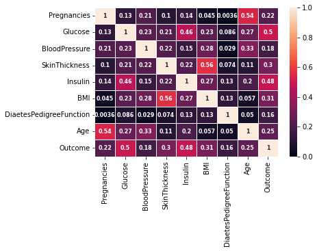

```python
correlations = data.corr()
correction=abs(correlations)
fig = plt.figure()
ax = sns.heatmap(correction, linewidths=0.5,vmax=1, vmin=0 ,annot=True,annot_kws={'size':8,'weight':'bold'})
plt.xticks(np.arange(9)+0.5)
plt.yticks(np.arange(9)+0.5)
plt.show()
```

## Section: 3.2 - Did you decide to implement any freature transformations? If so, why?

- If you decided you wanted to change any features, describe why and how and for what purposes. Feel free (though not required) to use mathematical notation where appropriate after providing an explanation.

### MinMax scaler

The MinMax scaler is one of the simplest scalers to understand. It just scales all the data between 0 and 1. The formula for calculating the scaled value is-

$$ x_{scaled} = (x – x_{min})/(x_{max} – x_{min}) $$

Thus, a point to note is that it does so for every feature separately. Though (0, 1) is the default range, we can define our range of max and min values as well

```python
data_transform=data.copy()
col_names = data_transform.columns[:-1]
features = data_transform[col_names]

scaler = MinMaxScaler(feature_range=(2,4))
data_transform[col_names] = scaler.fit_transform(features.values)
data_transform
```

|  | Pregnancies | Glucose | BloodPressure | SkinThickness | Insulin | BMI | DiaetesPedigreeFunction | Age | Outcome |
| --- | --- | --- | --- | --- | --- | --- | --- | --- | --- |
| 0 | 2.588235 | 3.290323 | 3.348837 | 2.678571 | 3.742765 | 2.867925 | 2.672058 | 3.450980 | 1 |
| 1 | 2.588235 | 3.200000 | 3.953488 | 2.915278 | 2.972891 | 3.924528 | 2.267745 | 2.627451 | 1 |
| 2 | 2.588235 | 2.838710 | 3.186047 | 2.678571 | 2.635682 | 3.119497 | 2.840970 | 3.529412 | 0 |
| 3 | 2.352941 | 2.890323 | 2.604651 | 2.107143 | 2.456592 | 2.710692 | 2.984726 | 2.156863 | 0 |
| 4 | 2.235294 | 2.670968 | 3.023256 | 2.214286 | 2.225080 | 2.182390 | 3.022462 | 2.196078 | 0 |
| ... | ... | ... | ... | ... | ... | ... | ... | ... | ... |
| 778 | 2.117647 | 2.348387 | 2.558140 | 2.392857 | 2.398714 | 2.138365 | 2.440252 | 2.039216 | 0 |
| 779 | 2.235294 | 2.877419 | 3.255814 | 3.535714 | 2.810289 | 3.333333 | 2.174304 | 2.117647 | 0 |
| 780 | 2.000000 | 3.212903 | 3.191214 | 2.915278 | 2.972891 | 3.138365 | 3.536388 | 2.156863 | 1 |
| 781 | 2.470588 | 3.793548 | 3.191214 | 2.915278 | 2.972891 | 2.641509 | 2.240791 | 2.588235 | 1 |
| 782 | 2.941176 | 3.793548 | 3.186047 | 2.915278 | 2.972891 | 2.320755 | 3.067385 | 2.431373 | 1 |

768 rows × 9 columns

### Log scaler

If you have a distribution of data where the larger distribution is more scattered, and the smaller distribution is more concentrated, you can take a log and get them close to symmetry. If the larger distribution is more concentrated, and the smaller distribution is more dispersed, you should use an exponential transformation to make them nearly symmetric.

```python
data_transform[col_names]=np.log(data_transform[col_names])
data_transform
```

|  | Pregnancies | Glucose | BloodPressure | SkinThickness | Insulin | BMI | DiaetesPedigreeFunction | Age | Outcome |
| --- | --- | --- | --- | --- | --- | --- | --- | --- | --- |
| 0 | 0.950976 | 1.190986 | 1.208613 | 0.985284 | 1.319825 | 1.053589 | 0.982849 | 1.238658 | 1 |
| 1 | 0.950976 | 1.163151 | 1.374598 | 1.069965 | 1.089535 | 1.367246 | 0.818786 | 0.966014 | 1 |
| 2 | 0.950976 | 1.043350 | 1.158781 | 0.985284 | 0.969142 | 1.137672 | 1.044146 | 1.261131 | 0 |
| 3 | 0.855666 | 1.061368 | 0.957299 | 0.745333 | 0.898775 | 0.997204 | 1.093508 | 0.768655 | 0 |
| 4 | 0.804373 | 0.982441 | 1.106334 | 0.794930 | 0.799793 | 0.780421 | 1.106072 | 0.786673 | 0 |
| ... | ... | ... | ... | ... | ... | ... | ... | ... | ... |
| 778 | 0.750306 | 0.853729 | 0.939280 | 0.872488 | 0.874933 | 0.760041 | 0.892101 | 0.712565 | 0 |
| 779 | 0.804373 | 1.056894 | 1.180442 | 1.262915 | 1.033287 | 1.203973 | 0.776708 | 0.750306 | 0 |
| 780 | 0.693147 | 1.167175 | 1.160402 | 1.069965 | 1.089535 | 1.143702 | 1.263106 | 0.768655 | 1 |
| 781 | 0.904456 | 1.333302 | 1.160402 | 1.069965 | 1.089535 | 0.971351 | 0.806829 | 0.950976 | 1 |
| 782 | 1.078810 | 1.333302 | 1.158781 | 1.069965 | 1.089535 | 0.841892 | 1.120826 | 0.888456 | 1 |

768 rows × 9 columns

## Section: 3.3 - Did you decide to create any new features? If so, why?

- If you decided you wanted to create any features, describe why and how and for what purposes. Feel free (though not required) to use mathematical notation where appropriate after providing an explanation.

### Create the "Insulin & Glucose", “Insulin & Glucose","BMI & SkinThickness"new feature

The outcome has the highest correlation with Glucose and Insulin levels, according to the updated heatmap. There is also a strong correlation between Glucose and Insulin levels. So I'm going to combine these two attributes to create a new attribute. “Insulin & Glucose","BMI & SkinThickness": They're also correlated.

```python
data_transform['Insulin & Glucose'] = data_transform['Insulin']/data_transform['Glucose']
data_transform['Age & Pregnancies'] = data_transform['Age']/data_transform['Pregnancies']
data_transform['BMI & SkinThickness'] = data_transform['BMI']/data_transform['SkinThickness']
data_transform
```

|  | Pregnancies | Glucose | BloodPressure | SkinThickness | Insulin | BMI | DiaetesPedigreeFunction | Age | Outcome | Insulin & Glucose | Age & Pregnancies | BMI & SkinThickness |
| --- | --- | --- | --- | --- | --- | --- | --- | --- | --- | --- | --- | --- |
| 0 | 0.950976 | 1.190986 | 1.208613 | 0.985284 | 1.319825 | 1.053589 | 0.982849 | 1.238658 | 1 | 1.108179 | 1.302512 | 1.069325 |
| 1 | 0.950976 | 1.163151 | 1.374598 | 1.069965 | 1.089535 | 1.367246 | 0.818786 | 0.966014 | 1 | 0.936710 | 1.015813 | 1.277842 |
| 2 | 0.950976 | 1.043350 | 1.158781 | 0.985284 | 0.969142 | 1.137672 | 1.044146 | 1.261131 | 0 | 0.928875 | 1.326144 | 1.154664 |
| 3 | 0.855666 | 1.061368 | 0.957299 | 0.745333 | 0.898775 | 0.997204 | 1.093508 | 0.768655 | 0 | 0.846808 | 0.898312 | 1.337931 |
| 4 | 0.804373 | 0.982441 | 1.106334 | 0.794930 | 0.799793 | 0.780421 | 1.106072 | 0.786673 | 0 | 0.814088 | 0.977996 | 0.981748 |
| ... | ... | ... | ... | ... | ... | ... | ... | ... | ... | ... | ... | ... |
| 778 | 0.750306 | 0.853729 | 0.939280 | 0.872488 | 0.874933 | 0.760041 | 0.892101 | 0.712565 | 0 | 1.024837 | 0.949700 | 0.871120 |
| 779 | 0.804373 | 1.056894 | 1.180442 | 1.262915 | 1.033287 | 1.203973 | 0.776708 | 0.750306 | 0 | 0.977664 | 0.932783 | 0.953328 |
| 780 | 0.693147 | 1.167175 | 1.160402 | 1.069965 | 1.089535 | 1.143702 | 1.263106 | 0.768655 | 1 | 0.933480 | 1.108934 | 1.068915 |
| 781 | 0.904456 | 1.333302 | 1.160402 | 1.069965 | 1.089535 | 0.971351 | 0.806829 | 0.950976 | 1 | 0.817171 | 1.051434 | 0.907834 |
| 782 | 1.078810 | 1.333302 | 1.158781 | 1.069965 | 1.089535 | 0.841892 | 1.120826 | 0.888456 | 1 | 0.817171 | 0.823552 | 0.786841 |

768 rows × 12 columns

## Section: 3.4 - Fit a logistic regression model using the data before any transformations or additions (e.g., the data at the end of section 3.2)

- Here we want to evaluate the model. Given an interpretation and an analysis.

### Output:

- Show the model output, coefficients, p-values and other relevant statistical information.
- Provide the odds ratios of the significant parameters as well as an interpretation of that odd's ratio. Be sure to mention what level of significance you are using.
- Assuming you use a cutoff of $\pi_i > 0.5$ when classifying diabetes what is your misclassification table.
- Assuming you use a cutoff of $\pi_i > 0.75$ when classifying diabetes what is your misclassification table.

> Bonus: Plot an ROC curve and describe it.

```python
#extract independent variables
train_cols=data.columns[:-1]
#fit the binary logit model
logit=sm.Logit(data['Outcome'],sm.add_constant(data[train_cols]))
result=logit.fit()
#display the result
print(result.summary())
```

```
Optimization terminated successfully.
         Current function value: 0.415098
         Iterations 7
                           Logit Regression Results
==============================================================================
Dep. Variable:                Outcome   No. Observations:                  768
Model:                          Logit   Df Residuals:                      759
Method:                           MLE   Df Model:                            8
Date:                Mon, 20 Sep 2021   Pseudo R-squ.:                  0.3582
Time:                        21:21:13   Log-Likelihood:                -318.80
converged:                       True   LL-Null:                       -496.74
Covariance Type:            nonrobust   LLR p-value:                 4.999e-72
===========================================================================================
                              coef    std err          z      P>|z|      [0.025      0.975]
-------------------------------------------------------------------------------------------
const                     -10.7982      0.948    -11.394      0.000     -12.656      -8.941
Pregnancies                 0.1086      0.033      3.328      0.001       0.045       0.173
Glucose                     0.0297      0.004      7.681      0.000       0.022       0.037
BloodPressure              -0.0042      0.009     -0.460      0.645      -0.022       0.014
SkinThickness               0.0510      0.014      3.582      0.000       0.023       0.079
Insulin                     0.0178      0.002      7.476      0.000       0.013       0.022
BMI                         0.0430      0.020      2.188      0.029       0.004       0.081
DiaetesPedigreeFunction     0.9132      0.403      2.267      0.023       0.124       1.703
Age                         0.0143      0.010      1.446      0.148      -0.005       0.034
===========================================================================================
```

```python
#odds ratio only
print(np.exp(result.params))
```

```
const                      0.000020
Pregnancies                1.114744
Glucose                    1.030098
BloodPressure              0.995762
SkinThickness              1.052361
Insulin                    1.017978
BMI                        1.043914
DiaetesPedigreeFunction    2.492233
Age                        1.014421
dtype: float64
```

```python
#odds ratio and 95% CI
params=result.params
conf=result.conf_int()
conf['OR']=params
conf.columns=['2.5%','97.5%','OR']
print(np.exp(conf))
```

```
                             2.5%     97.5%        OR
const                    0.000003  0.000131  0.000020
Pregnancies              1.045666  1.188385  1.114744
Glucose                  1.022333  1.037922  1.030098
BloodPressure            0.977915  1.013934  0.995762
SkinThickness            1.023384  1.082159  1.052361
Insulin                  1.013234  1.022744  1.017978
BMI                      1.004495  1.084880  1.043914
DiaetesPedigreeFunction  1.131466  5.489538  2.492233
Age                      0.994923  1.034301  1.014421
```

```python
predicted_probs = result.predict( sm.add_constant(data[train_cols]))
predicted_probs
```

```
0      0.936451
1      0.688544
2      0.249950
3      0.042634
4      0.009790
         ...
778    0.006506
779    0.413872
780    0.587767
781    0.782999
782    0.865563
Length: 768, dtype: float64
```

```python
def table(predicted_probs, labels, cutoff):
    """ Replacement for R's table funcion. """
    predicted_outcome = (predicted_probs > cutoff).astype(int)
    df = pd.DataFrame({"predicted_outcome": predicted_outcome, "actual_outcome": labels})
    return pd.crosstab(index=df["actual_outcome"], columns=df["predicted_outcome"], margins=False)

table(predicted_probs, data["Outcome"], cutoff=0.5)
```

| predicted_outcome actual_outcome | 0 | 1 |
| --- | --- | --- |
| 0 | 441 | 59 |
| 1 | 89 | 179 |

```python
table(predicted_probs, data["Outcome"], cutoff=0.75)
```

| predicted_outcome actual_outcome | 0 | 1 |
| --- | --- | --- |
| 0 | 480 | 20 |
| 1 | 159 | 109 |

```python
#extract independent variables
train_cols=data.columns[:-1]
x=data[train_cols]
y=data['Outcome']
x_train,x_test,y_train,y_test=train_test_split(x,y,test_size=0.2)
model = LogisticRegression(fit_intercept = True, penalty = 'none',max_iter=5000).fit(x_train, y_train)
y_pred = model.predict(x_test)
print('The accurarcy score id:', accuracy_score(y_test,y_pred)*100)
```

```
The accurarcy score id: 81.16883116883116
```

```python
model.coef_
```

```
array([[ 0.1092648 ,  0.0277624 , -0.00886691,  0.04419119,  0.01632856,
         0.04704945,  1.03514531,  0.02175276]])
```

```python
#odds ratio only
print(np.exp(model.coef_))
```

```
[[1.11545768 1.02815137 0.99117228 1.04518217 1.0164626  1.04817384
  2.81551532 1.02199108]]
```

```python
model.intercept_
```

```
array([-10.24707421])
```

```python
y_pre=model.predict_proba(x)
y_pre
```

```
array([[0.06864527, 0.93135473],
       [0.34940945, 0.65059055],
       [0.68652158, 0.31347842],
       ...,
       [0.43158839, 0.56841161],
       [0.25294046, 0.74705954],
       [0.15826106, 0.84173894]])
```

```python
predicted_probs-y_pre[:,1]
```

```
0      0.005096
1      0.037953
2     -0.063529
3     -0.013840
4     -0.002782
         ...
778   -0.001794
779    0.049920
780    0.019356
781    0.035940
782    0.023824
Length: 768, dtype: float64
```

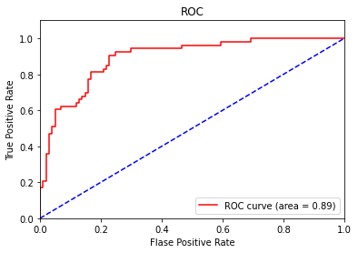

```python
y_pre=model.predict_proba(x_test)
y_pre=y_pre[:,1]
fpr,tpr,thresholds=roc_curve(y_test,y_pre)
auc=roc_auc_score(y_test,y_pre)

plt.figure()
plt.plot(fpr, tpr, color='red', label='ROC curve (area = %0.2f)' % auc)
plt.plot([0,1],[0,1],color='blue',linestyle='--')
plt.xlim([0.0,1.0])
plt.ylim([0.0,1.1])
plt.xlabel('Flase Positive Rate')
plt.ylabel('True Positive Rate')
plt.title('ROC')
plt.legend(loc="lower right")
plt.show()
```

## Section: 3.5 - Fit a logistic regression model using the data after your feature transformations and new variables.

- Here we want to see if you were able to discover features that led to an improve moodel

### Output:

- Show the model output, coefficients, p-values and other relevant statistical information.
- Provide the odds ratios of the significant parameters as well as an interpretation of that odd's ratio. Be sure to mention what level of significance you are using.
- Assuming you use a cuttoff of $\pi_i > 0.5$ when classifying diabetes what is your misclassification table.
- Assuming you use a cutoff of $\pi_i > 0.75$ when classifying diabetes what is your misclassification table.

> Bonus: Plot an ROC curve and describe it.

```python
#extract independent variables
feature=data_transform.copy()
feature=feature.drop(columns=['Outcome','Insulin & Glucose','BMI & SkinThickness'])
train_cols=feature.columns
#fit the binary logit model
logit=sm.Logit(data_transform['Outcome'],sm.add_constant(data_transform[train_cols]))
result=logit.fit()
#display the result
print(result.summary())
```

```
Optimization terminated successfully.
         Current function value: 0.402176
         Iterations 7
                           Logit Regression Results
==============================================================================
Dep. Variable:                Outcome   No. Observations:                  768
Model:                          Logit   Df Residuals:                      758
Method:                           MLE   Df Model:                            9
Date:                Mon, 20 Sep 2021   Pseudo R-squ.:                  0.3782
Time:                        21:21:13   Log-Likelihood:                -308.87
converged:                       True   LL-Null:                       -496.74
Covariance Type:            nonrobust   LLR p-value:                 2.041e-75
===========================================================================================
                              coef    std err          z      P>|z|      [0.025      0.975]
-------------------------------------------------------------------------------------------
const                     -36.5275      3.994     -9.145      0.000     -44.356     -28.699
Pregnancies                12.7660      3.702      3.449      0.001       5.510      20.021
Glucose                     7.1848      0.957      7.509      0.000       5.310       9.060
BloodPressure              -0.8176      1.261     -0.649      0.517      -3.289       1.653
SkinThickness               3.9016      1.160      3.363      0.001       1.627       6.176
Insulin                     8.5337      1.097      7.776      0.000       6.383      10.685
BMI                         2.1272      0.935      2.274      0.023       0.294       3.960
DiaetesPedigreeFunction     1.4429      0.634      2.274      0.023       0.199       2.686
Age                        -9.3944      3.697     -2.541      0.011     -16.640      -2.149
Age & Pregnancies           9.2509      3.138      2.948      0.003       3.100      15.402
===========================================================================================
```

```python
#odds ratio only
print(np.exp(result.params))
```

```
const                      1.368688e-16
Pregnancies                3.500945e+05
Glucose                    1.319235e+03
BloodPressure              4.414691e-01
SkinThickness              4.948001e+01
Insulin                    5.083408e+03
BMI                        8.391490e+00
DiaetesPedigreeFunction    4.232840e+00
Age                        8.318765e-05
Age & Pregnancies          1.041415e+04
dtype: float64
```

```python
#odds ratio and 95% CI
params=result.params
conf=result.conf_int()
conf['OR']=params
conf.columns=['2.5%','97.5%','OR']
print(np.exp(conf))
```

```
                                 2.5%         97.5%            OR
const                    5.450231e-20  3.437115e-13  1.368688e-16
Pregnancies              2.472738e+02  4.956696e+08  3.500945e+05
Glucose                  2.022521e+02  8.605012e+03  1.319235e+03
BloodPressure            3.730402e-02  5.224504e+00  4.414691e-01
SkinThickness            5.090894e+00  4.809118e+02  4.948001e+01
Insulin                  5.915173e+02  4.368603e+04  5.083408e+03
BMI                      1.341936e+00  5.247428e+01  8.391490e+00
DiaetesPedigreeFunction  1.220523e+00  1.467972e+01  4.232840e+00
Age                      5.934721e-08  1.166051e-01  8.318765e-05
Age & Pregnancies        2.219708e+01  4.885976e+06  1.041415e+04
```

```python
predicted_probs = result.predict( sm.add_constant(data_transform[train_cols]))
predicted_probs
```

```
0      0.913797
1      0.674794
2      0.201502
3      0.032451
4      0.005142
         ...
778    0.003278
779    0.349067
780    0.628004
781    0.758616
782    0.883820
Length: 768, dtype: float64
```

```python
def table(predicted_probs, labels, cutoff):
    """ Replacement for R's table funcion. """
    predicted_outcome = (predicted_probs > cutoff).astype(int)
    df = pd.DataFrame({"predicted_outcome": predicted_outcome, "actual_outcome": labels})
    return pd.crosstab(index=df["actual_outcome"], columns=df["predicted_outcome"], margins=False)

table(predicted_probs, data_transform["Outcome"], cutoff=0.5)
```

| predicted_outcome actual_outcome | 0 | 1 |
| --- | --- | --- |
| 0 | 444 | 56 |
| 1 | 84 | 184 |

```python
table(predicted_probs, data_transform["Outcome"], cutoff=0.75)
```

| predicted_outcome actual_outcome | 0 | 1 |
| --- | --- | --- |
| 0 | 481 | 19 |
| 1 | 153 | 115 |

```python
#extract independent variables
x=data_transform[train_cols]
y=data_transform['Outcome']
x_train,x_test,y_train,y_test=train_test_split(x,y,test_size=0.2)
model = LogisticRegression(fit_intercept = True, penalty = 'none',max_iter=5000).fit(x_train, y_train)
y_pred = model.predict(x_test)
print('The accurarcy score id:', accuracy_score(y_test,y_pred)*100)
```

```
The accurarcy score id: 81.81818181818183
```

```python
model.coef_
```

```
array([[10.49003817,  7.61756596, -0.50649999,  3.33079114,  7.69974826,
         2.22793245,  1.07184393, -7.33052179,  7.37422498]])
```

```python
#odds ratio only
print(np.exp(model.coef_))
```

```
[[3.59555299e+04 2.03360622e+03 6.02601004e-01 2.79604535e+01
  2.20779212e+03 9.28065802e+00 2.92076022e+00 6.55231603e-04
  1.59435569e+03]]
```

```python
model.intercept_
```

```
array([-33.69697668])
```

```python
y_pre=model.predict_proba(x)
y_pre
```

```
array([[0.10823156, 0.89176844],
       [0.32539012, 0.67460988],
       [0.80659982, 0.19340018],
       ...,
       [0.43161562, 0.56838438],
       [0.24530541, 0.75469459],
       [0.14435402, 0.85564598]])
```

```python
predicted_probs-y_pre[:,1]
```

```
0      0.022028
1      0.000184
2      0.008102
3     -0.001956
4     -0.000566
         ...
778    0.000030
779    0.028278
780    0.059620
781    0.003921
782    0.028174
Length: 768, dtype: float64
```

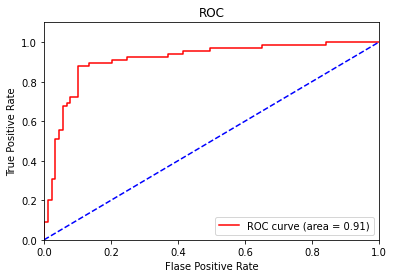

```python
y_pre=model.predict_proba(x_test)
y_pre=y_pre[:,1]
fpr,tpr,thresholds=roc_curve(y_test,y_pre)
auc=roc_auc_score(y_test,y_pre)

plt.figure()
plt.plot(fpr, tpr, color='red', label='ROC curve (area = %0.2f)' % auc)
plt.plot([0,1],[0,1],color='blue',linestyle='--')
plt.xlim([0.0,1.0])
plt.ylim([0.0,1.1])
plt.xlabel('Flase Positive Rate')
plt.ylabel('True Positive Rate')
plt.title('ROC')
plt.legend(loc="lower right")
plt.show()
```

# Section: 4 - Conclusions

- What are your overall conclusions about the data?
- What did you learn? What would you explore further with additional data, time or resources. What might "future research" require to gain deeper insight?

### Overall conclusions about the data:

> - The correlation between outcome and individual characteristic attributes was verified from section 3.4.
> - The correlation between outcome and combinations of attributes was verified from section 3.5.
> - The accuracy of current predictions is still not particularly good.

### Learn from the homework:

> - Cleaning data is important to redefine the correlation of feature attributes.
> - There are a number of techniques for how to transform characteristic attributes. The units and data densities may differ between attributes. These differences have led me to use different transition techniques.
> - Creating new attributes is also difficult and important. It required me to think deeply about the interconnections of related attributes.

### Future research：

> - If I had more time, I would try out more attribute transform techniques, and I would also like to try out more ways to create new attributes. I believe that the attribute transform and new attributes I made were shallow and arbitrary.
> - With more data, I believe the results could be more accurate and the bias might be smaller. At the same time, I can select useful features from more data for focused research.
> - If I had more medical resources, I would know more about the relationship between attributes and the relationship between attributes and predicted outcomes. So my predictions would be based not just on math, but more on medicine.Or my mathematical evidence will be based on medical evidence. Such evidence would make the results more convincing.